# Medium Range Radar Users Guide

### Running the Lab PC-GUI

1. Navigate to the folder **gui ► MRRvisualization** and click on **MRRVISUALIZER.exe**
2. Windows should open. (i.e. a Display prompt window and a GUI window)
   - If the EVM is connected to the PC, then the display prompt window should successfully open the COM ports (to double check, make sure they match with the port numbers on the Device Manager).

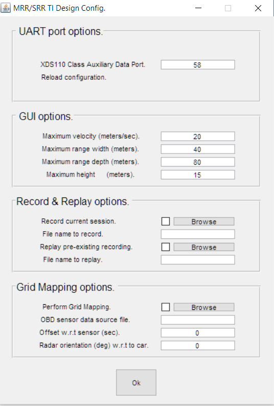

1. In the GUI window, fill in the Data COM Port field. (Make sure that no other EVM is connected to the USB ports of the PC)
2. After filling all the options. Click “Ok”

[figure not shown]

The Matlab GUI consists of 5 components:

- **X-Y scatter plot:** Displays the positions of the point clouds, the tracks, and the cluster.
- **Y-Z scatter plot:** Displays the positions of the point clouds in elevation.
- **Doppler range plot:** Displays the Doppler-range coordinates of the point cloud and the clusters.
- **Legend:** Description of the different kinds of points being displayed on the screen.
- **Display options:** Displays the different types of the point cloud can be enabled and disabled at the user’s discretion during demonstration.

### Display Options

At startup, the following are the default GUI Display Options:

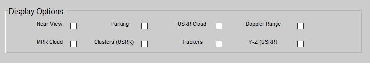

Following are recommended settings for each mode.

#### MRR Mode

- **MRR Cloud** should be enabled at a minimum to display the point cloud detected by MRR frames (green dots).
- **Doppler Range** should be enabled if we want to see the doppler information.
- **Trackers** should be enabled if we want to see the tracked clusters.

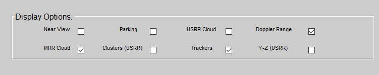

#### USRR Mode

- **USRR Cloud** should be enabled at a minimum to display the point cloud detected by USRR frames (blue dots)
- **Clusters** should be enabled to display the clusters based on USRR frames.
- **Y-Z** should be enabled to display the Y-Z elevation information for USRR detected points.
- **Near View** can be enabled to increase the scale of the Y-Z view.
- **Parking** can be enabled if it is desired to define a parking border.

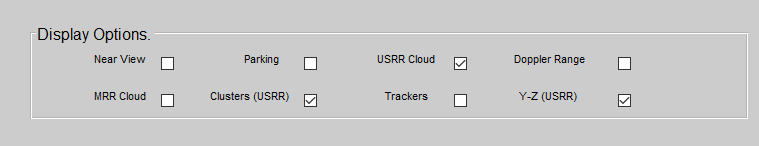

#### MRR/USRR Mode

- In MRR/USRR mode we recommend enabling first the minimum options: **MRR Cloud, USRR Cloud and Trackers**
- If there are rich point clouds it is possible that the GUI freezes.
  - This may happen when current frame display is not completed before next frame data becomes available.
  - This will depend on the environment and on the PC processing power.

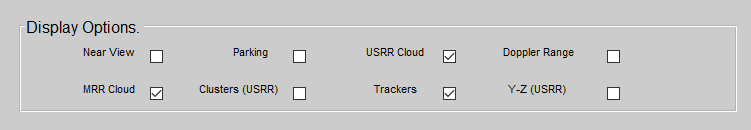

# Learn more about TI mmWave Sensors

Learn more about xWR1x devices, please visit the product pages:

- AWR1443
- AWR1642
- AWR1843

Get started evaluating the platform with xWR1x EVMs, purchase EVM at:

- [AWR1443 EVM](http://www.ti.com/tool/AWR1443BOOST)
- [AWR1642 EVM](http://www.ti.com/tool/AWR1642BOOST)
- [AWR1843 EVM](http://www.ti.com/tool/AWR1843BOOST)

Download [mmWave SDK](http://www.ti.com/tool/MMWAVE-SDK)  
Ask question on TI’s [E2E forum](http://e2e.ti.com)